# Fun with NA’s

2021-01-28

## Learning Goals

*At the end of this exercise, you will be able to:*  
1. Define `NA` and describe how they are treated in R.  
2. Produce summaries of the number of NA’s in a data set.  
3. Replace values with `NA` in a data set as appropriate.

## Install the packages `naniar` and `visdat`

We will use these in part 2 of today’s lab.

```r
#install.packages("naniar")
#install.packages("visdat")
```

## Load the libraries

```r
library("tidyverse")
library("naniar")
library("skimr")
library("janitor")
```

## Dealing with NA’s

In almost all large data sets, there are missing observations. These can be tricky to deal with, partly because you first need to determine how missing values were treated in the original study. In a given data set, NA might represent values that are unrecorded because they are unknown or missing. But, they can also represent data that are not applicable.

Scientists use different conventions in showing missing data; some use blank spaces, others use “-”, etc. Unfortunately, sometimes **missing data is indicated with numbers like -999.0 or zero!**, though this can be required in some situations (for example raster data). Often, a combination of methods are used. It is up to the data analyst to find out how missing values are represented in the data set and to deal with them appropriately. Remember, if missing data are represented by values then R will treat them as such and you could be misled.

(There are missing observations in every data set. This can be tricky, because it’s not always clear how NAs are represented. Ex.-999, or 0. The latter is a huge problem because R will treat it as a 0, so the calculations you do will be wrong, but that’s only because the 0s that are meant to be NAs were incorporated, not your fault!)

## For the following examples, we will use the built-in `msleep` data

```r
?msleep
```

## Are there any NA’s?

The `summary()` function in base R will tally NA’s by variable, but only for categorical/factor, numeric, integer, or logical columns. What about any NA values in the character columns?

(We can just run a summary function to check this. Important to look at the output, and summary conveniently outputs NA values, but these are only NAs that R interprets, not necessarily the actual NA values. However, in the case of this dataset, the summary is accurate!)

```r
summary(msleep)
```

```
##      name              genus               vore              order
##  Length:83          Length:83          Length:83          Length:83
##  Class :character   Class :character   Class :character   Class :character
##  Mode  :character   Mode  :character   Mode  :character   Mode  :character
##
##
##
##
##  conservation        sleep_total      sleep_rem      sleep_cycle
##  Length:83          Min.   : 1.90   Min.   :0.100   Min.   :0.1167
##  Class :character   1st Qu.: 7.85   1st Qu.:0.900   1st Qu.:0.1833
##  Mode  :character   Median :10.10   Median :1.500   Median :0.3333
##                     Mean   :10.43   Mean   :1.875   Mean   :0.4396
##                     3rd Qu.:13.75   3rd Qu.:2.400   3rd Qu.:0.5792
##                     Max.   :19.90   Max.   :6.600   Max.   :1.5000
##                                     NA's   :22      NA's   :51
##      awake          brainwt            bodywt
##  Min.   : 4.10   Min.   :0.00014   Min.   :   0.005
##  1st Qu.:10.25   1st Qu.:0.00290   1st Qu.:   0.174
##  Median :13.90   Median :0.01240   Median :   1.670
##  Mean   :13.57   Mean   :0.28158   Mean   : 166.136
##  3rd Qu.:16.15   3rd Qu.:0.12550   3rd Qu.:  41.750
##  Max.   :22.10   Max.   :5.71200   Max.   :6654.000
##                  NA's   :27
```

Let’s next check to see if our data has any NA’s by evaluating everything logically. We have done this before, but this is a good time to review. `is.na()` is a function that determines whether a value in a data frame is or is not an NA. This is evaluated as TRUE or FALSE. This means that R is looking in the data for NA, not for any values that might represent NA. To R, and NA is an empty cell or spot in a vector.

Keep in mind, if the authors of the data represented NA’s in another way, they will not be detected by R.

(We get logical output for every cell, kind of a mess and a lot of stuff to look at. Don’t really know where any of these data are, where they’re concentrated, or prospects on how to deal with them.)

```r
is.na(msleep)
```

```
##        name genus  vore order conservation sleep_total sleep_rem sleep_cycle
##  [1,] FALSE FALSE FALSE FALSE        FALSE       FALSE      TRUE        TRUE
##  [2,] FALSE FALSE FALSE FALSE         TRUE       FALSE     FALSE        TRUE
##  [3,] FALSE FALSE FALSE FALSE        FALSE       FALSE     FALSE        TRUE
##  [4,] FALSE FALSE FALSE FALSE        FALSE       FALSE     FALSE       FALSE
##  [5,] FALSE FALSE FALSE FALSE        FALSE       FALSE     FALSE       FALSE
##  [6,] FALSE FALSE FALSE FALSE         TRUE       FALSE     FALSE       FALSE
##  [7,] FALSE FALSE FALSE FALSE        FALSE       FALSE     FALSE       FALSE
##  [8,] FALSE FALSE  TRUE FALSE         TRUE       FALSE      TRUE        TRUE
##  [9,] FALSE FALSE FALSE FALSE        FALSE       FALSE     FALSE       FALSE
## [10,] FALSE FALSE FALSE FALSE        FALSE       FALSE      TRUE        TRUE
## [11,] FALSE FALSE FALSE FALSE        FALSE       FALSE     FALSE        TRUE
## [12,] FALSE FALSE FALSE FALSE        FALSE       FALSE     FALSE       FALSE
## [13,] FALSE FALSE FALSE FALSE        FALSE       FALSE     FALSE        TRUE
## [14,] FALSE FALSE FALSE FALSE        FALSE       FALSE     FALSE       FALSE
```

[output cut: 153 more lines]

We also learned…

```r
any_na(msleep)
```

```
## [1] TRUE
```

What are we supposed to do with those? Unless you have a very small data frame, applying these functions is not helpful but we can use them in another way. Let’s incorporate `is.na` into `summarize()`.

(This gives us a number that tells us how many NAs are there! The 136 NAs could be concentrated in one or more variables)

```r
msleep %>%
  summarize(number_nas = sum(is.na(msleep)))
```

```
## # A tibble: 1 x 1
##   number_nas
##        <int>
## 1        136
```

This is better, but we still don’t have any idea of where those NA’s are in our data. With such limited information, it would be hard to determine if the issue was systemic or isolated to a single variable. In order to do this, we can apply `is.na()` to each variable of interest- which would be very slow!

(So checking how many NAs are in conservation.)

```r
msleep %>%
  summarize(number_nas = sum(is.na(conservation)))
```

```
## # A tibble: 1 x 1
##   number_nas
##        <int>
## 1         29
```

Here we summarize the number of NA’s over all of the variables.

(This gives us an idea of where NAs are concentrated in the dataframe!)

```r
msleep %>%
  summarise_all(~(sum(is.na(.))))
```

```
## # A tibble: 1 x 11
##    name genus  vore order conservation sleep_total sleep_rem sleep_cycle awake
##   <int> <int> <int> <int>        <int>       <int>     <int>       <int> <int>
## 1     0     0     7     0           29           0        22          51     0
## # … with 2 more variables: brainwt <int>, bodywt <int>
```

## NA’s using `purr`

What if we are working with hundreds or thousands of variables?! In order to deal with this problem efficiently we can use another package in the tidyverse called `purrr`. We will talk more about `purr` later, but for now let’s have a look!

This handy bit of code generates a new data frame that sums all NA’s across variables. This does the same thing as above, but it is faster.

(Exact same output as previous summary, but you can do a lot more with this function.)

```r
msleep %>%
  purrr::map_df(~ sum(is.na(.))) #map to a new data frame the sum results of the is.na function for all columns
```

```
## # A tibble: 1 x 11
##    name genus  vore order conservation sleep_total sleep_rem sleep_cycle awake
##   <int> <int> <int> <int>        <int>       <int>     <int>       <int> <int>
## 1     0     0     7     0           29           0        22          51     0
## # … with 2 more variables: brainwt <int>, bodywt <int>
```

We can use `pivot_longer()` to make viewing this output easier. We are covering pivots next week.

(Gives us a nice tally of where NAs are most abundant. This helps us because we can scroll through and see where the NAs make sense. Get an idea of how the NAs are distributed in the data.)

```r
msleep %>%
  purrr::map_df(~ sum(is.na(.))) %>%
  pivot_longer(everything(),
    names_to= "variables",
    values_to = "num_nas") %>%
  arrange(desc(num_nas))
```

```
## # A tibble: 11 x 2
##    variables    num_nas
##    <chr>          <int>
##  1 sleep_cycle       51
##  2 conservation      29
##  3 brainwt           27
##  4 sleep_rem         22
##  5 vore               7
##  6 name               0
##  7 genus              0
##  8 order              0
##  9 sleep_total        0
## 10 awake              0
## 11 bodywt             0
```

This is much better, but we need to be careful. R can have difficulty interpreting missing data. This is especially true for categorical variables. Always do a reality check if the output doesn’t make sense to you. A quick check never hurts and can save you from wasting time in the future or from drawing false conclusions.

(Never hurts to make sure data values make sense!)

You can explore a specific variable using `count()`. Remember this works the same way as `group_by()` and `summarize()`.

```r
msleep %>%
  count(conservation)
```

```
## # A tibble: 7 x 2
##   conservation     n
## * <chr>        <int>
## 1 cd               2
## 2 domesticated    10
## 3 en               4
## 4 lc              27
## 5 nt               4
## 6 vu               7
## 7 <NA>            29
```

(We get same number as is.na function, so that’s a good reality check. Might seem redundant, but just because your code works doesn’t mean it really did what you wanted it to, so important you run those checks, especially if the data are familiar to you!)

Adding the `sort=TRUE` option automatically makes a descending list. We confirm that there are 29 NA’s within the conservation variable.

```r
msleep %>%
  count(conservation, sort = TRUE)
```

```
## # A tibble: 7 x 2
##   conservation     n
##   <chr>        <int>
## 1 <NA>            29
## 2 lc              27
## 3 domesticated    10
## 4 vu               7
## 5 en               4
## 6 nt               4
## 7 cd               2
```

It is true that all of this is redundant, but you want to be able to run multiple checks on the data. Remember, just because your code runs without errors doesn’t mean it is doing what you intended.

## Practice

For this practice we will use amniote life history data from: Myhrvold N, Baldridge E, Chan B, Sivam D, Freeman DL, Ernest SKM (2015). “An amniote life-history database to perform comparative analyses with birds, mammals, and reptiles.” *Ecology*, *96*, 3109. doi: 10.1890/15-0846.1 (URL: https://doi.org/10.1890/15-0846.1).

1. Load the `amniota` data below and determine whether or not NA’s are present. If they are present, how are they represented?

```r
amniota <- readr::read_csv("data/amniota.csv")
summary(amniota)
```

```
##     class              order              family             genus
##  Length:21322       Length:21322       Length:21322       Length:21322
##  Class :character   Class :character   Class :character   Class :character
##  Mode  :character   Mode  :character   Mode  :character   Mode  :character
##
##
##
##    species            subspecies   common_name        female_maturity_d
##  Length:21322       Min.   :-999   Length:21322       Min.   :-30258.7
##  Class :character   1st Qu.:-999   Class :character   1st Qu.:  -999.0
##  Mode  :character   Median :-999   Mode  :character   Median :  -999.0
##                     Mean   :-999                      Mean   :  -723.7
##                     3rd Qu.:-999                      3rd Qu.:  -999.0
##                     Max.   :-999                      Max.   :  9131.2
##  litter_or_clutch_size_n litters_or_clutches_per_y adult_body_mass_g
##  Min.   :-999.000        Min.   :-999.0            Min.   :     -999
##  1st Qu.:-999.000        1st Qu.:-999.0            1st Qu.:        4
##  Median :   1.692        Median :-999.0            Median :       24
##  Mean   :-383.909        Mean   :-766.8            Mean   :    29107
##  3rd Qu.:   3.200        3rd Qu.:-999.0            3rd Qu.:      135
##  Max.   : 156.000        Max.   :  52.0            Max.   :149000000
##  maximum_longevity_y  gestation_d       weaning_d
##  Min.   :-999.000    Min.   :-999.0   Min.   :-999.0
##  1st Qu.:-999.000    1st Qu.:-999.0   1st Qu.:-999.0
##  Median :-999.000    Median :-999.0   Median :-999.0
##  Mean   :-737.061    Mean   :-874.9   Mean   :-892.4
##  3rd Qu.:   1.083    3rd Qu.:-999.0   3rd Qu.:-999.0
##  Max.   : 211.000    Max.   :7396.9   Max.   :1826.2
##  birth_or_hatching_weight_g weaning_weight_g     egg_mass_g
##  Min.   :   -999.0          Min.   :    -999   Min.   :-999.00
##  1st Qu.:   -999.0          1st Qu.:    -999   1st Qu.:-999.00
##  Median :   -999.0          Median :    -999   Median :-999.00
##  Mean   :    -88.6          Mean   :    1116   Mean   :-739.64
##  3rd Qu.:   -999.0          3rd Qu.:    -999   3rd Qu.:   0.56
##  Max.   :2250000.0          Max.   :17000000   Max.   :1500.00
##   incubation_d    fledging_age_d    longevity_y       male_maturity_d
##  Min.   :-999.0   Min.   :-999.0   Min.   :-999.000   Min.   :-999.0
##  1st Qu.:-999.0   1st Qu.:-999.0   1st Qu.:-999.000   1st Qu.:-999.0
##  Median :-999.0   Median :-999.0   Median :-999.000   Median :-999.0
##  Mean   :-820.5   Mean   :-909.4   Mean   :-737.821   Mean   :-827.8
```

[output cut: 22 more lines]

```
##  Max.   :3049.000   Max.   : 315.2   Max.   :1125.0   Max.   : 760.0
##  female_svl_at_maturity_cm female_body_mass_at_maturity_g no_sex_svl_cm
##  Min.   :-999.0            Min.   :  -999.0               Min.   :-999.0
##  1st Qu.:-999.0            1st Qu.:  -999.0               1st Qu.:-999.0
##  Median :-999.0            Median :  -999.0               Median :-999.0
##  Mean   :-989.4            Mean   :  -980.6               Mean   :-747.1
##  3rd Qu.:-999.0            3rd Qu.:  -999.0               3rd Qu.:-999.0
##  Max.   : 580.0            Max.   :194000.0               Max.   :3300.0
##  no_sex_maturity_d
##  Min.   : -999.0
##  1st Qu.: -999.0
##  Median : -999.0
##  Mean   : -942.6
##  3rd Qu.: -999.0
##  Max.   :14610.0
```

There are issues here, as -999 pops up everywhere across the frame

2. Use one of the tools explained above to summarize NA’s in the data.

```r
amniota %>%
  summarise_all(~(sum(is.na(.)))) #sum, is.na is across all of the variables. If sum goes across all the variables, it should work. However, this is saying there are no NAs, which we no isn't true. R isn't seeing them because NAs are being represented by actual values
```

```
## # A tibble: 1 x 36
##   class order family genus species subspecies common_name female_maturity…
##   <int> <int>  <int> <int>   <int>      <int>       <int>            <int>
## 1     0     0      0     0       0          0           0                0
## # … with 28 more variables: litter_or_clutch_size_n <int>,
## #   litters_or_clutches_per_y <int>, adult_body_mass_g <int>,
## #   maximum_longevity_y <int>, gestation_d <int>, weaning_d <int>,
## #   birth_or_hatching_weight_g <int>, weaning_weight_g <int>, egg_mass_g <int>,
## #   incubation_d <int>, fledging_age_d <int>, longevity_y <int>,
## #   male_maturity_d <int>, inter_litter_or_interbirth_interval_y <int>,
## #   female_body_mass_g <int>, male_body_mass_g <int>, no_sex_body_mass_g <int>,
## #   egg_width_mm <int>, egg_length_mm <int>, fledging_mass_g <int>,
## #   adult_svl_cm <int>, male_svl_cm <int>, female_svl_cm <int>,
## #   birth_or_hatching_svl_cm <int>, female_svl_at_maturity_cm <int>,
## #   female_body_mass_at_maturity_g <int>, no_sex_svl_cm <int>,
## #   no_sex_maturity_d <int>
```

Trying to figure out where the NAs are.

3. What’s going on here? Try using the `hist` function on one or more of the continuous variables.

(Doing a histogram check of ex. egg mass. You can see that egg mass shouldn’t have huge mass of negative values)

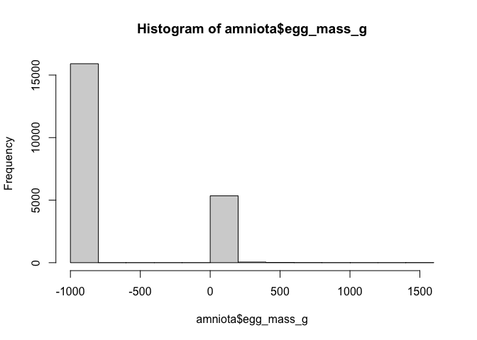

```r
hist(amniota$egg_mass_g)
```

4. Given that we know that the output of #2 is wrong, what do you think is the best approach for dealing with NA’s in the `amniote` data?

(Replace every -999 value with NA. There’s a number of different ways to do this! One way to do this is in Excel, and it’s pretty analogous to what we’re doing here. (Search and replace.) However, in Excel, you’re hiding what you’re thinking about or how you’re progressing with your calculations. Key to datascience is to keep things transparent)

```r
amniota_no_nas <- amniota %>%
  na_if("-999") #Same function shown below!
```

## Replacing values with NA

If you are certain that NA’s are represented by a specific value in the data, the best way to deal with them is to replace the value with NA. This is similar to a find & replace function in excel. Although you can do this when you import the data, in most cases you will need to (and should!) do some exploration first.

*A note on excel:* you may find yourself tempted to just open the .csv in excel and use find & replace. But, this isn’t transparent; i.e. you are manipulating the data in a way that others can’t see so this is not good practice in data science.

Let’s say we know that NA’s are represented by “-999” in `amniota`. We can replace this value with NA across the data frame. You might be tempted to overwrite `amniota`, but in these cases I like to make a new object.

```r
amniota_tidy <- amniota %>%  #Making a new dataframe, because want to retain old values and being transparent with what you're changing
  na_if("-999")
```

Now let’s run that function from problem #2 again to see how we did.

```r
amniota_tidy %>%
  summarise_all(~(sum(is.na(.))))
```

```
## # A tibble: 1 x 36
##   class order family genus species subspecies common_name female_maturity…
##   <int> <int>  <int> <int>   <int>      <int>       <int>            <int>
## 1     0     0      0     0       0      21322        1641            17849
## # … with 28 more variables: litter_or_clutch_size_n <int>,
## #   litters_or_clutches_per_y <int>, adult_body_mass_g <int>,
## #   maximum_longevity_y <int>, gestation_d <int>, weaning_d <int>,
## #   birth_or_hatching_weight_g <int>, weaning_weight_g <int>, egg_mass_g <int>,
## #   incubation_d <int>, fledging_age_d <int>, longevity_y <int>,
## #   male_maturity_d <int>, inter_litter_or_interbirth_interval_y <int>,
## #   female_body_mass_g <int>, male_body_mass_g <int>, no_sex_body_mass_g <int>,
## #   egg_width_mm <int>, egg_length_mm <int>, fledging_mass_g <int>,
## #   adult_svl_cm <int>, male_svl_cm <int>, female_svl_cm <int>,
## #   birth_or_hatching_svl_cm <int>, female_svl_at_maturity_cm <int>,
## #   female_body_mass_at_maturity_g <int>, no_sex_svl_cm <int>,
## #   no_sex_maturity_d <int>
```

(Now running summarize function and you see the variables, a lof of which has a lot of missing data! Shows two different meanings ot NAs: 1: Scientist hasn’t recorded data 2: That data doesn’t exist)

Wow, that is a lot of missing data! Let’s try `purr`. For a large data set like `amniota` this is very convenient.

```r
amniota_tidy %>%
  purrr::map_df(~ sum(is.na(.))) %>%
  pivot_longer(everything(),
    names_to= "variables",
    values_to = "num_nas") %>%
  arrange(desc(num_nas))
```

```
## # A tibble: 36 x 2
##    variables                      num_nas
##    <chr>                            <int>
##  1 subspecies                       21322
##  2 female_body_mass_at_maturity_g   21318
##  3 female_svl_at_maturity_cm        21120
##  4 fledging_mass_g                  21111
##  5 male_svl_cm                      21040
##  6 no_sex_maturity_d                20860
##  7 egg_width_mm                     20727
##  8 egg_length_mm                    20702
##  9 weaning_weight_g                 20258
## 10 female_svl_cm                    20242
## # … with 26 more rows
```

Saying that all the animals in this dataframe don’t have a subspecies. This isn’t necessarily missing data, but rather not applicable data. Ex. egg width/length might be missing because we don’t have those values for other animals.

## Replacing NAs with `na_if()` and `mutate()`

On occasion, we may want to treat recorded data as NA. To do this, we need to use `na_if` and `mutate()`. Let’s switch to the built-in `msleep` data to keep things clear.

```r
names(msleep)
```

```
##  [1] "name"         "genus"        "vore"         "order"        "conservation"
##  [6] "sleep_total"  "sleep_rem"    "sleep_cycle"  "awake"        "brainwt"
## [11] "bodywt"
```

Let’s say we want to treat “domesticated” as NA in the conservation column. First, how many NA’s are present in the variable `conservation`?

```r
msleep %>%
  count(conservation, sort=T)
```

```
## # A tibble: 7 x 2
##   conservation     n
##   <chr>        <int>
## 1 <NA>            29
## 2 lc              27
## 3 domesticated    10
## 4 vu               7
## 5 en               4
## 6 nt               4
## 7 cd               2
```

Now, let’s change all instances of `domesticated` to NA.

```r
msleep %>%
  mutate(conservation_modified = na_if(conservation, "domesticated"))%>% #Conservation_modified is the name of the new column. It's very important that you don't just replace an existing column, but rather create an entirely new one. Na_if in the column conservation, we see domesticated. If you treat domesticated NA, you should see 39
  count(conservation_modified, sort = T) #previously there were only 29 NA's
```

```
## # A tibble: 6 x 2
##   conservation_modified     n
##   <chr>                 <int>
## 1 <NA>                     39
## 2 lc                       27
## 3 vu                        7
## 4 en                        4
## 5 nt                        4
## 6 cd                        2
```

This is handy for looking through a particular column.

## Practice

For the following examples, we will use the `life_history` data for mammals. The [data](http://esapubs.org/archive/ecol/E084/093/) are from:  
**S. K. Morgan Ernest. 2003. Life history characteristics of placental non-volant mammals. Ecology 84:3402.**

1. Load the mammals life history data v2. Do you see any NA’s?

```r
life_history <- readr::read_csv("data/mammal_lifehistories_v2.csv")
#Readr is a package in the tidyverse, so you don't need to have it there, but the reason why it's there is so that people understand that you are using that function!
```

2. Explore the data using any method that you prefer. `skimr` provides a nice output with histograms for numeric variables.

```r
life_history %>%
  skimr::skim()
```

Data summary

| Name | Piped data |
| --- | --- |
| Number of rows | 1440 |
| Number of columns | 13 |
| _______________________ |  |
| Column type frequency: |  |
| character | 4 |
| numeric | 9 |
| ________________________ |  |
| Group variables | None |

**Variable type: character**

| skim_variable | n_missing | complete_rate | min | max | empty | n_unique | whitespace |
| --- | --- | --- | --- | --- | --- | --- | --- |
| order | 0 | 1 | 7 | 14 | 0 | 17 | 0 |
| family | 0 | 1 | 6 | 15 | 0 | 96 | 0 |
| Genus | 0 | 1 | 3 | 16 | 0 | 618 | 0 |
| species | 0 | 1 | 3 | 17 | 0 | 1191 | 0 |

**Variable type: numeric**

| skim_variable | n_missing | complete_rate | mean | sd | p0 | p25 | p50 | p75 | p100 | hist |
| --- | --- | --- | --- | --- | --- | --- | --- | --- | --- | --- |
| mass | 0 | 1 | 383576.72 | 5055162.92 | -999 | 50 | 403.02 | 7009.17 | 1.4900e+08 | ▇▁▁▁▁ |
| gestation | 0 | 1 | -287.25 | 455.36 | -999 | -999 | 1.05 | 4.50 | 2.1460e+01 | ▃▁▁▁▇ |
| newborn | 0 | 1 | 6703.15 | 90912.52 | -999 | -999 | 2.65 | 98.00 | 2.2500e+06 | ▇▁▁▁▁ |
| weaning | 0 | 1 | -427.17 | 496.71 | -999 | -999 | 0.73 | 2.00 | 4.8000e+01 | ▆▁▁▁▇ |
| wean mass | 0 | 1 | 16048.93 | 503650.17 | -999 | -999 | -999.00 | 10.00 | 1.9075e+07 | ▇▁▁▁▁ |
| AFR | 0 | 1 | -408.12 | 504.97 | -999 | -999 | 2.50 | 15.61 | 2.1000e+02 | ▆▁▁▁▇ |
| max. life | 0 | 1 | -490.26 | 615.30 | -999 | -999 | -999.00 | 147.25 | 1.3680e+03 | ▇▁▅▁▁ |
| litter size | 0 | 1 | -55.63 | 234.88 | -999 | 1 | 2.27 | 3.84 | 1.4180e+01 | ▁▁▁▁▇ |
| litters/year | 0 | 1 | -477.14 | 500.03 | -999 | -999 | 0.38 | 1.15 | 7.5000e+00 | ▇▁▁▁▇ |

Odd distributions, -999 values, so there are NA values that are at least represented by -999

3. Replace the entries that represent NA’s in the data using `na_if()`. Double check your work.

```r
life_history_tidy <- life_history %>%  #Remember, making a whole new dataframe but retaining the original data!
  na_if("-999")
```

```r
life_history_tidy %>%
  skimr::skim()
```

Data summary

| Name | Piped data |
| --- | --- |
| Number of rows | 1440 |
| Number of columns | 13 |
| _______________________ |  |
| Column type frequency: |  |
| character | 4 |
| numeric | 9 |
| ________________________ |  |
| Group variables | None |

**Variable type: character**

| skim_variable | n_missing | complete_rate | min | max | empty | n_unique | whitespace |
| --- | --- | --- | --- | --- | --- | --- | --- |
| order | 0 | 1 | 7 | 14 | 0 | 17 | 0 |
| family | 0 | 1 | 6 | 15 | 0 | 96 | 0 |
| Genus | 0 | 1 | 3 | 16 | 0 | 618 | 0 |
| species | 0 | 1 | 3 | 17 | 0 | 1191 | 0 |

**Variable type: numeric**

| skim_variable | n_missing | complete_rate | mean | sd | p0 | p25 | p50 | p75 | p100 | hist |
| --- | --- | --- | --- | --- | --- | --- | --- | --- | --- | --- |
| mass | 85 | 0.94 | 407701.39 | 5210474.99 | 2.10 | 61.15 | 606.00 | 8554.00 | 1.4900e+08 | ▇▁▁▁▁ |
| gestation | 418 | 0.71 | 3.86 | 3.62 | 0.49 | 0.99 | 2.11 | 6.00 | 2.1460e+01 | ▇▃▁▁▁ |
| newborn | 595 | 0.59 | 12126.55 | 118408.21 | 0.21 | 4.40 | 43.70 | 542.50 | 2.2500e+06 | ▇▁▁▁▁ |
| weaning | 619 | 0.57 | 3.97 | 5.38 | 0.30 | 0.92 | 1.69 | 4.84 | 4.8000e+01 | ▇▁▁▁▁ |
| wean mass | 1039 | 0.28 | 60220.50 | 953857.17 | 2.09 | 20.15 | 102.60 | 2000.00 | 1.9075e+07 | ▇▁▁▁▁ |
| AFR | 607 | 0.58 | 22.44 | 26.45 | 0.70 | 4.50 | 12.00 | 28.24 | 2.1000e+02 | ▇▁▁▁▁ |
| max. life | 841 | 0.42 | 224.03 | 189.74 | 12.00 | 84.00 | 192.00 | 288.00 | 1.3680e+03 | ▇▂▁▁▁ |
| litter size | 84 | 0.94 | 2.80 | 1.77 | 1.00 | 1.02 | 2.50 | 4.00 | 1.4180e+01 | ▇▃▁▁▁ |
| litters/year | 689 | 0.52 | 1.64 | 1.17 | 0.14 | 1.00 | 1.00 | 2.00 | 7.5000e+00 | ▇▃▁▁▁ |

```r
life_history_tidy %>%
  summarize(number_nas=sum(is.na(life_history_tidy))) #Shows you the total number of NAs in the dataframe
```

```
## # A tibble: 1 x 1
##   number_nas
##        <int>
## 1       4977
```

4. In which variable are the most NAs in the data frame?

(Trying to see where the NAs are concentrated)

```r
life_history_tidy %>%
  purrr::map_df(~ sum(is.na(.))) %>%
  pivot_longer(everything(),
    names_to= "variables",
    values_to = "num_nas") %>%
  arrange(desc(num_nas))
```

```
## # A tibble: 13 x 2
##    variables    num_nas
##    <chr>          <int>
##  1 wean mass       1039
##  2 max. life        841
##  3 litters/year     689
##  4 weaning          619
##  5 AFR              607
##  6 newborn          595
##  7 gestation        418
##  8 mass              85
##  9 litter size       84
## 10 order              0
## 11 family             0
## 12 Genus              0
## 13 species            0
```

## That’s it! Take a break and I will see you on Zoom!

–>[Home](https://jmledford3115.github.io/datascibiol/)